# NYPD Shooting Incident

Sorabh Kaila

2024-07-09

# Analysis of NY shooting incidents from 2005 to 2023 and understand the trends, underlying factors etc.

## Import NYPD shooting data from the city of New York website (url below).

## This gives details such as data by Borough, location of incident, ## murder(y/n), age - group/sex/race of victim and perpeterator etc.

```r
##install.packages("tidyverse")
library(tidyverse)
url = "https://data.cityofnewyork.us/api/views/833y-fsy8/rows.csv?accessType=DOWNLOAD"
ny = read_csv(url)
head(ny)
```

```
## # A tibble: 6 × 21
##   INCIDENT_KEY OCCUR_DATE OCCUR_TIME BORO      LOC_OF_OCCUR_DESC PRECINCT
##          <dbl> <chr>      <time>     <chr>     <chr>                <dbl>
## 1    244608249 05/05/2022 00:10      MANHATTAN INSIDE                  14
## 2    247542571 07/04/2022 22:20      BRONX     OUTSIDE                 48
## 3     84967535 05/27/2012 19:35      QUEENS    <NA>                   103
## 4    202853370 09/24/2019 21:00      BRONX     <NA>                    42
## 5     27078636 02/25/2007 21:00      BROOKLYN  <NA>                    83
## 6    230311078 07/01/2021 23:07      MANHATTAN <NA>                    23
## # ℹ 15 more variables: JURISDICTION_CODE <dbl>, LOC_CLASSFCTN_DESC <chr>,
## #   LOCATION_DESC <chr>, STATISTICAL_MURDER_FLAG <lgl>, PERP_AGE_GROUP <chr>,
## #   PERP_SEX <chr>, PERP_RACE <chr>, VIC_AGE_GROUP <chr>, VIC_SEX <chr>,
## #   VIC_RACE <chr>, X_COORD_CD <dbl>, Y_COORD_CD <dbl>, Latitude <dbl>,
## #   Longitude <dbl>, Lon_Lat <chr>
```

## Summary of the data

```r
summary(ny)
```

```
##   INCIDENT_KEY        OCCUR_DATE         OCCUR_TIME           BORO
##  Min.   :  9953245   Length:28562       Length:28562      Length:28562
##  1st Qu.: 65439914   Class :character   Class1:hms        Class :character
##  Median : 92711254   Mode  :character   Class2:difftime   Mode  :character
##  Mean   :127405824                      Mode  :numeric
##  3rd Qu.:203131993
##  Max.   :279758069
##
##  LOC_OF_OCCUR_DESC     PRECINCT     JURISDICTION_CODE LOC_CLASSFCTN_DESC
##  Length:28562       Min.   :  1.0   Min.   :0.0000    Length:28562
##  Class :character   1st Qu.: 44.0   1st Qu.:0.0000    Class :character
##  Mode  :character   Median : 67.0   Median :0.0000    Mode  :character
##                     Mean   : 65.5   Mean   :0.3219
##                     3rd Qu.: 81.0   3rd Qu.:0.0000
##                     Max.   :123.0   Max.   :2.0000
##                                     NA's   :2
##  LOCATION_DESC      STATISTICAL_MURDER_FLAG PERP_AGE_GROUP
##  Length:28562       Mode :logical           Length:28562
##  Class :character   FALSE:23036             Class :character
##  Mode  :character   TRUE :5526              Mode  :character
##
##
##
##
##    PERP_SEX          PERP_RACE         VIC_AGE_GROUP        VIC_SEX
##  Length:28562       Length:28562       Length:28562       Length:28562
##  Class :character   Class :character   Class :character   Class :character
##  Mode  :character   Mode  :character   Mode  :character   Mode  :character
##
##
##
##
##    VIC_RACE           X_COORD_CD        Y_COORD_CD        Latitude
##  Length:28562       Min.   : 914928   Min.   :125757   Min.   :40.51
##  Class :character   1st Qu.:1000068   1st Qu.:182912   1st Qu.:40.67
##  Mode  :character   Median :1007772   Median :194901   Median :40.70
##                     Mean   :1009424   Mean   :208380   Mean   :40.74
##                     3rd Qu.:1016807   3rd Qu.:239814   3rd Qu.:40.82
##                     Max.   :1066815   Max.   :271128   Max.   :40.91
##                                                        NA's   :59
##    Longitude        Lon_Lat
##  Min.   :-74.25   Length:28562
##  1st Qu.:-73.94   Class :character
##  Median :-73.92   Mode  :character
##  Mean   :-73.91
##  3rd Qu.:-73.88
##  Max.   :-73.70
##  NA's   :59
```

## Transforming Data

### Remove columns not needed

```r
ny = subset(ny,select = -c(X_COORD_CD,Y_COORD_CD,Latitude, Longitude, Lon_Lat))
summary(ny)
```

```
##   INCIDENT_KEY        OCCUR_DATE         OCCUR_TIME           BORO
##  Min.   :  9953245   Length:28562       Length:28562      Length:28562
##  1st Qu.: 65439914   Class :character   Class1:hms        Class :character
##  Median : 92711254   Mode  :character   Class2:difftime   Mode  :character
##  Mean   :127405824                      Mode  :numeric
##  3rd Qu.:203131993
##  Max.   :279758069
##
##  LOC_OF_OCCUR_DESC     PRECINCT     JURISDICTION_CODE LOC_CLASSFCTN_DESC
##  Length:28562       Min.   :  1.0   Min.   :0.0000    Length:28562
##  Class :character   1st Qu.: 44.0   1st Qu.:0.0000    Class :character
##  Mode  :character   Median : 67.0   Median :0.0000    Mode  :character
##                     Mean   : 65.5   Mean   :0.3219
##                     3rd Qu.: 81.0   3rd Qu.:0.0000
##                     Max.   :123.0   Max.   :2.0000
##                                     NA's   :2
##  LOCATION_DESC      STATISTICAL_MURDER_FLAG PERP_AGE_GROUP
##  Length:28562       Mode :logical           Length:28562
##  Class :character   FALSE:23036             Class :character
##  Mode  :character   TRUE :5526              Mode  :character
##
##
##
##
##    PERP_SEX          PERP_RACE         VIC_AGE_GROUP        VIC_SEX
##  Length:28562       Length:28562       Length:28562       Length:28562
##  Class :character   Class :character   Class :character   Class :character
##  Mode  :character   Mode  :character   Mode  :character   Mode  :character
##
##
##
##
##    VIC_RACE
##  Length:28562
##  Class :character
##  Mode  :character
##
##
##
##
```

### Change format of columns

```r
library(lubridate)
ny = ny%>%mutate(ny, OCCUR_DATE = mdy(OCCUR_DATE))
ny$PRECINCT = as.character(ny$PRECINCT)
ny$JURISDICTION_CODE = as.character(ny$JURISDICTION_CODE)

summary(ny)
```

```
##   INCIDENT_KEY         OCCUR_DATE          OCCUR_TIME           BORO
##  Min.   :  9953245   Min.   :2006-01-01   Length:28562      Length:28562
##  1st Qu.: 65439914   1st Qu.:2009-09-04   Class1:hms        Class :character
##  Median : 92711254   Median :2013-09-20   Class2:difftime   Mode  :character
##  Mean   :127405824   Mean   :2014-06-07   Mode  :numeric
##  3rd Qu.:203131993   3rd Qu.:2019-09-29
##  Max.   :279758069   Max.   :2023-12-29
##  LOC_OF_OCCUR_DESC    PRECINCT         JURISDICTION_CODE  LOC_CLASSFCTN_DESC
##  Length:28562       Length:28562       Length:28562       Length:28562
##  Class :character   Class :character   Class :character   Class :character
##  Mode  :character   Mode  :character   Mode  :character   Mode  :character
##
##
##
##  LOCATION_DESC      STATISTICAL_MURDER_FLAG PERP_AGE_GROUP
##  Length:28562       Mode :logical           Length:28562
##  Class :character   FALSE:23036             Class :character
##  Mode  :character   TRUE :5526              Mode  :character
##
##
##
##    PERP_SEX          PERP_RACE         VIC_AGE_GROUP        VIC_SEX
##  Length:28562       Length:28562       Length:28562       Length:28562
##  Class :character   Class :character   Class :character   Class :character
##  Mode  :character   Mode  :character   Mode  :character   Mode  :character
##
##
##
##    VIC_RACE
##  Length:28562
##  Class :character
##  Mode  :character
##
##
##
```

### Extract hour of day from Occur_time

```r
ny$OCCUR_TIME = hour(ny$OCCUR_TIME)
head(ny$OCCUR_TIME)
```

```
## [1]  0 22 19 21 21 23
```

### Count of Missing Values

```r
sapply(ny,function(x) sum(is.na(x)))
```

```
##            INCIDENT_KEY              OCCUR_DATE              OCCUR_TIME
##                       0                       0                       0
##                    BORO       LOC_OF_OCCUR_DESC                PRECINCT
##                       0                   25596                       0
##       JURISDICTION_CODE      LOC_CLASSFCTN_DESC           LOCATION_DESC
##                       2                   25596                   14977
## STATISTICAL_MURDER_FLAG          PERP_AGE_GROUP                PERP_SEX
##                       0                    9344                    9310
##               PERP_RACE           VIC_AGE_GROUP                 VIC_SEX
##                    9310                       0                       0
##                VIC_RACE
##                       0
```

### Since most values are missing for Loc_of_occur & Loc_classfctn, drop these columns

```r
ny = subset(ny,select = -c(LOC_OF_OCCUR_DESC,LOC_CLASSFCTN_DESC))
```

### There are a lot of missing values in Location_Desc, Perp_Age_Group, Perp_Sex and Perp_Race but we will these fields as is for now as we may need them for analysis later.

## Data Analysis and Visualization

### Trend by Year and Month

```r
ny = ny%>%mutate(ny, OCCUR_YEAR = year(OCCUR_DATE))
head(ny$OCCUR_YEAR)
```

```
## [1] 2022 2022 2012 2019 2007 2021
```

```r
ny_year_total = ny %>% group_by(OCCUR_YEAR) %>% tally
max(ny_year_total)
```

```
## [1] 2055
```

```r
min(ny_year_total)
```

```
## [1] 958
```

```r
mean(ny_year_total$n)
```

```
## [1] 1586.778
```

### Avg. cases per year is 1587. Min of 958 cases in 2018. Max 2055 in 2006. What would cause such a low number of cases in 2017-2019??

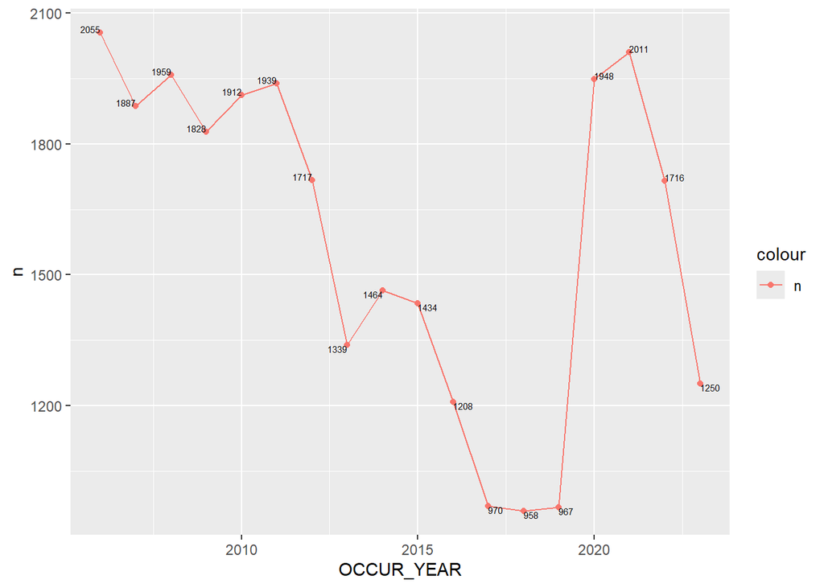

```r
par(mar = c(1, 1, 1, 1))
ny_year_total %>%
ggplot(aes(x=OCCUR_YEAR, y = n))+
geom_line(aes(color="n"))+
geom_point(aes(color="n"))+
  geom_text(aes(label=n),size=2,vjust="outward",hjust="outward")
```

### Incidents by Borough

```r
ny_borough_total = ny %>% group_by(BORO) %>% tally
ny_borough_total
```

```
## # A tibble: 5 × 2
##   BORO              n
##   <chr>         <int>
## 1 BRONX          8376
## 2 BROOKLYN      11346
## 3 MANHATTAN      3762
## 4 QUEENS         4271
## 5 STATEN ISLAND   807
```

### Max cases in Brooklyn and Min in Staten Islan

### Lets look at cases as % of population

### Pop Source https://www.citypopulation.de/en/usa/newyorkcity/

```r
pop = c(1356479,2561225,1594751,2252196,190687)
ny_borough_total = ny_borough_total %>% mutate(ny_borough_total,population = pop) %>% mutate(ny_borough_total,cases_per_pop = (n/population)*100)
```

### Bronx has the highest % followed by Brooklyn. Need to investigate what is causing Bronx crime rate to be this high compared to Queens which is extremely low?

## Visualize data by borough

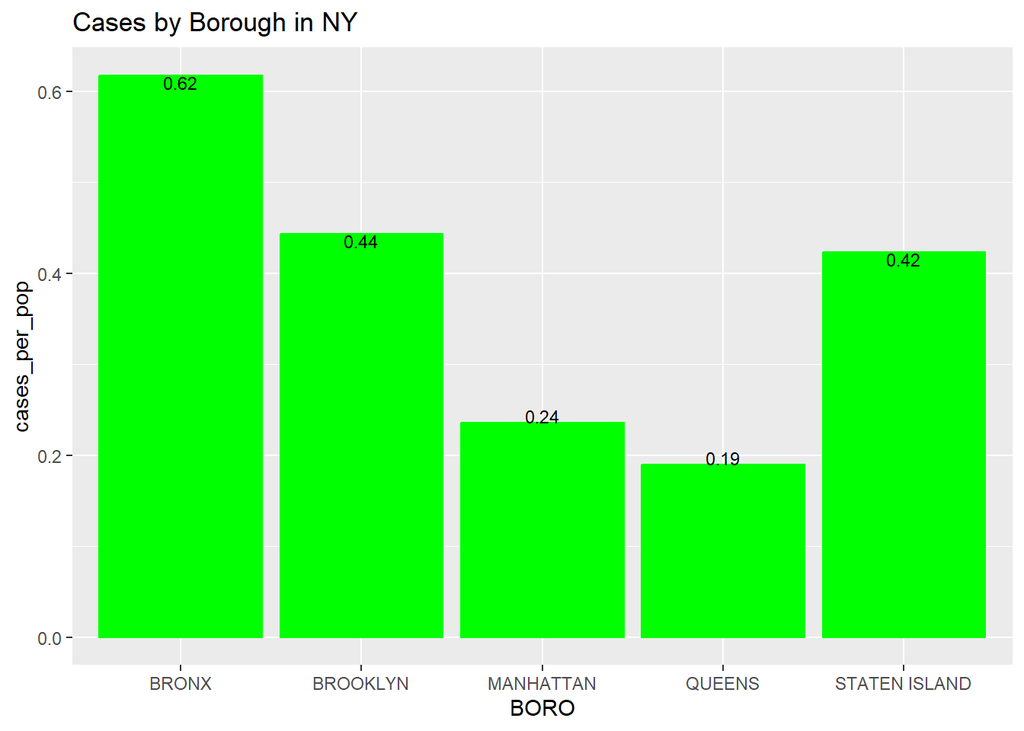

```r
ny_borough_total %>%
ggplot(aes(x=BORO, y = cases_per_pop))+
geom_bar(position='dodge',stat = 'identity',color='green',fill='green')+
  ggtitle("Cases by Borough in NY")+
  geom_text(aes(label = round(cases_per_pop,2)),size=3,color="black",vjust="inward")
```

## Visualize data by time of day

```r
ny_time = ny %>% group_by(OCCUR_TIME) %>% tally
ny_time
```

```
## # A tibble: 24 × 2
##    OCCUR_TIME     n
##         <int> <int>
##  1          0  2267
##  2          1  2142
##  3          2  1878
##  4          3  1666
##  5          4  1487
##  6          5   738
##  7          6   389
##  8          7   246
##  9          8   254
## 10          9   240
## # ℹ 14 more rows
```

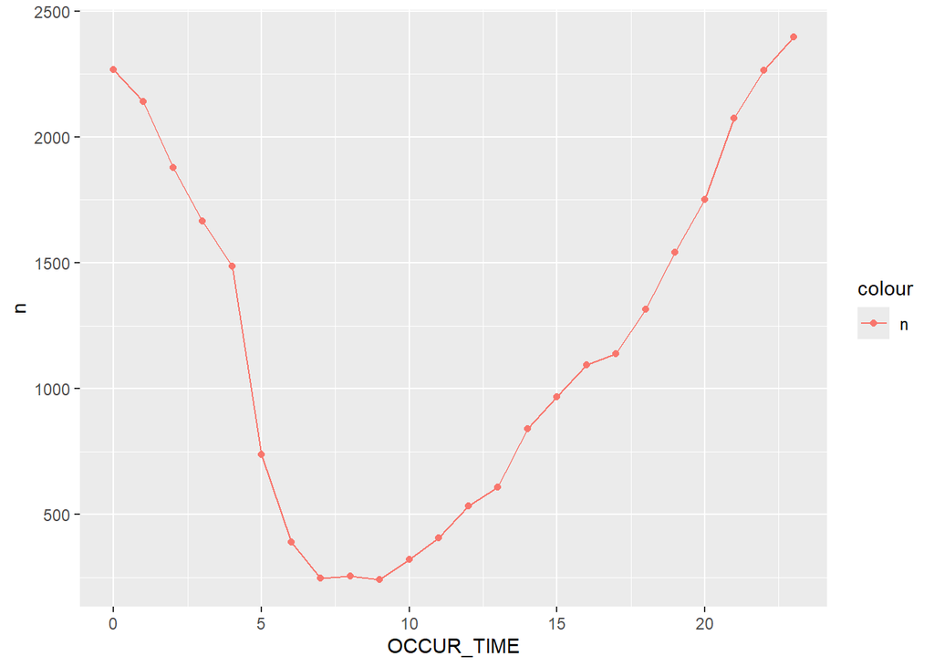

```r
ny_time %>% ggplot(aes(x=OCCUR_TIME, y = n))+
geom_line(aes(color="n"))+
geom_point(aes(color="n"))
```

## Visualize data by victim race

```r
ny_race = ny %>% group_by(VIC_RACE) %>% tally
ny_race
```

```
## # A tibble: 7 × 2
##   VIC_RACE                           n
##   <chr>                          <int>
## 1 AMERICAN INDIAN/ALASKAN NATIVE    11
## 2 ASIAN / PACIFIC ISLANDER         440
## 3 BLACK                          20235
## 4 BLACK HISPANIC                  2795
## 5 UNKNOWN                           70
## 6 WHITE                            728
## 7 WHITE HISPANIC                  4283
```

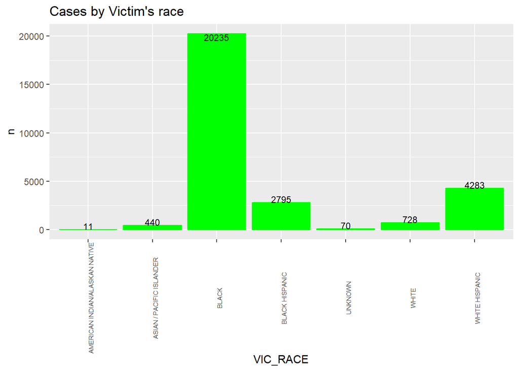

```r
ny_race %>%
ggplot(aes(x=VIC_RACE, y = n))+
geom_bar(position='dodge',stat = 'identity',color='green',fill='green')+
  ggtitle("Cases by Victim's race")+
  geom_text(aes(label = n),size=3,color="black",vjust="inward")+
  theme(axis.text.x = element_text(size=6, angle = 90))
```

## Bias in the data

### Looking at cases per borough, we are analyzing based on the population of a borough. That might be a bias in how data is measured for Bronx and Brooklyn compared to other Boroughs.

### There might be a change in NY shooting data from 2005 to 2023 and that would introduce bias in our analysis. We may need to understand how this data is measured and if there have been changes since 2005 that could explain some of the variances by year.

### Based on the initial analysis it does look like the cases reduced from 2005 to 2019 (lowest from 2017 to 2019). They started rising again from 2020 before coming down in 2023.Need to investigate further.

### Bronx and Brooklyn seems to have a very high shooting rate. Need to investigate what could be causing these high rates.